# Practical Machine Learning porject

Wangsik Kim

2016-10-28

Background

Using devices such as Jawbone Up, Nike FuelBand, and Fitbit it is now possible to collect a large amount of data about personal activity relatively inexpensively. These type of devices are part of the quantified self movement – a group of enthusiasts who take measurements about themselves regularly to improve their health, to find patterns in their behavior, or because they are tech geeks. One thing that people regularly do is quantify how much of a particular activity they do, but they rarely quantify how well they do it. In this project, your goal will be to use data from accelerometers on the belt, forearm, arm, and dumbell of 6 participants. They were asked to perform barbell lifts correctly and incorrectly in 5 different ways. More information is available from the website here: http://groupware.les.inf.puc-rio.br/har (see the section on the Weight Lifting Exercise Dataset).

Data

The training data for this project are available here:

https://d396qusza40orc.cloudfront.net/predmachlearn/pml-training.csv

The test data are available here:

https://d396qusza40orc.cloudfront.net/predmachlearn/pml-testing.csv

The data for this project come from this source: http://groupware.les.inf.puc-rio.br/har. If you use the document you create for this class for any purpose please cite them as they have been very generous in allowing their data to be used for this kind of assignment.

```r
library(caret)
library(kernlab)
library(lattice)
library(ggplot2)
library(rpart)
library(rattle)
library(rpart.plot)
library(purrr)
library(tidyr)
library(magrittr)
library(dplyr)
```

```r
# Load the training dataset
download.file(url = "https://d396qusza40orc.cloudfront.net/predmachlearn/pml-training.csv",
              destfile = "./pml-training.csv", method = "curl")


data_training <- read.csv("./pml-training.csv", na.strings=c("NA","#DIV/0!",""))


## Data partitioning
inTrain <- createDataPartition(y=data_training$classe,
                               p=0.75, list=FALSE)


training <- data_training[inTrain, ]
testing <- data_training[-inTrain, ]
dim(training); dim(testing)
```

```
## [1] 14718   160
```

```
## [1] 4904  160
```

```r
summary(data_training$classe)
```

```
##    A    B    C    D    E
## 5580 3797 3422 3216 3607
```

```r
##To check variables with missing values
apply(data_training,2,function(x) sum(is.na(x)))
```

```
##                        X                user_name     raw_timestamp_part_1
##                        0                        0                        0
##     raw_timestamp_part_2           cvtd_timestamp               new_window
##                        0                        0                        0
##               num_window                roll_belt               pitch_belt
##                        0                        0                        0
##                 yaw_belt         total_accel_belt       kurtosis_roll_belt
##                        0                        0                    19226
##      kurtosis_picth_belt        kurtosis_yaw_belt       skewness_roll_belt
##                    19248                    19622                    19225
##     skewness_roll_belt.1        skewness_yaw_belt            max_roll_belt
##                    19248                    19622                    19216
##           max_picth_belt             max_yaw_belt            min_roll_belt
##                    19216                    19226                    19216
##           min_pitch_belt             min_yaw_belt      amplitude_roll_belt
##                    19216                    19226                    19216
##     amplitude_pitch_belt       amplitude_yaw_belt     var_total_accel_belt
##                    19216                    19226                    19216
##            avg_roll_belt         stddev_roll_belt            var_roll_belt
##                    19216                    19216                    19216
##           avg_pitch_belt        stddev_pitch_belt           var_pitch_belt
##                    19216                    19216                    19216
##             avg_yaw_belt          stddev_yaw_belt             var_yaw_belt
##                    19216                    19216                    19216
##             gyros_belt_x             gyros_belt_y             gyros_belt_z
##                        0                        0                        0
##             accel_belt_x             accel_belt_y             accel_belt_z
##                        0                        0                        0
##            magnet_belt_x            magnet_belt_y            magnet_belt_z
##                        0                        0                        0
##                 roll_arm                pitch_arm                  yaw_arm
##                        0                        0                        0
##          total_accel_arm            var_accel_arm             avg_roll_arm
##                        0                    19216                    19216
##          stddev_roll_arm             var_roll_arm            avg_pitch_arm
##                    19216                    19216                    19216
##         stddev_pitch_arm            var_pitch_arm              avg_yaw_arm
##                    19216                    19216                    19216
##           stddev_yaw_arm              var_yaw_arm              gyros_arm_x
##                    19216                    19216                        0
```

[output cut: 53 more lines]

```
##                    19300                        0                    19216
##         avg_roll_forearm      stddev_roll_forearm         var_roll_forearm
##                    19216                    19216                    19216
##        avg_pitch_forearm     stddev_pitch_forearm        var_pitch_forearm
##                    19216                    19216                    19216
##          avg_yaw_forearm       stddev_yaw_forearm          var_yaw_forearm
##                    19216                    19216                    19216
##          gyros_forearm_x          gyros_forearm_y          gyros_forearm_z
##                        0                        0                        0
##          accel_forearm_x          accel_forearm_y          accel_forearm_z
##                        0                        0                        0
##         magnet_forearm_x         magnet_forearm_y         magnet_forearm_z
##                        0                        0                        0
##                   classe
##                        0
```

```r
### There are unnecessary variables in dataset
training_final <- training[, -c(1:7)]
testing_final <- testing[, -c(1:7)]

#Remove those columns with missing values (except classe column)

training_final_clean  <- training_final[ ,!names(training_final) %in% names(training_final)[apply(training_final, 2, anyNA)]]
testing_final_clean <- testing_final[ , !names(testing_final) %in% names(testing_final)[apply(testing_final, 2, anyNA)]]


names(training_final_clean)
```

```
##  [1] "roll_belt"            "pitch_belt"           "yaw_belt"
##  [4] "total_accel_belt"     "gyros_belt_x"         "gyros_belt_y"
##  [7] "gyros_belt_z"         "accel_belt_x"         "accel_belt_y"
## [10] "accel_belt_z"         "magnet_belt_x"        "magnet_belt_y"
## [13] "magnet_belt_z"        "roll_arm"             "pitch_arm"
## [16] "yaw_arm"              "total_accel_arm"      "gyros_arm_x"
## [19] "gyros_arm_y"          "gyros_arm_z"          "accel_arm_x"
## [22] "accel_arm_y"          "accel_arm_z"          "magnet_arm_x"
## [25] "magnet_arm_y"         "magnet_arm_z"         "roll_dumbbell"
## [28] "pitch_dumbbell"       "yaw_dumbbell"         "total_accel_dumbbell"
## [31] "gyros_dumbbell_x"     "gyros_dumbbell_y"     "gyros_dumbbell_z"
## [34] "accel_dumbbell_x"     "accel_dumbbell_y"     "accel_dumbbell_z"
## [37] "magnet_dumbbell_x"    "magnet_dumbbell_y"    "magnet_dumbbell_z"
## [40] "roll_forearm"         "pitch_forearm"        "yaw_forearm"
## [43] "total_accel_forearm"  "gyros_forearm_x"      "gyros_forearm_y"
## [46] "gyros_forearm_z"      "accel_forearm_x"      "accel_forearm_y"
## [49] "accel_forearm_z"      "magnet_forearm_x"     "magnet_forearm_y"
## [52] "magnet_forearm_z"     "classe"
```

Variale selection Sometimes, one may face a problem with many variable. It is a good practice to check plot by a group of variable to identify importance of variables. I highlighted and demonstrated some of key findings.

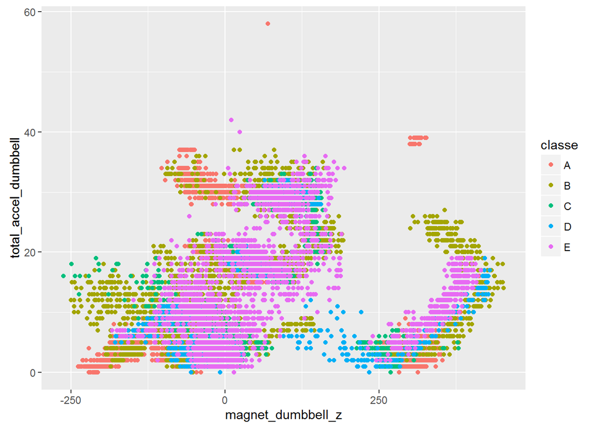

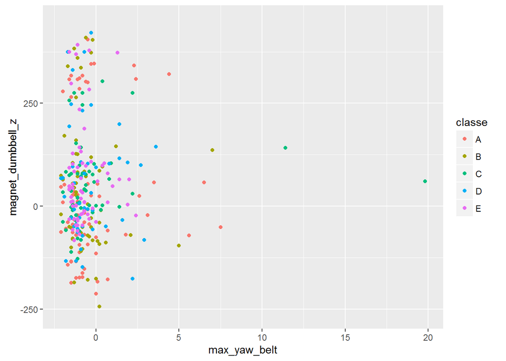

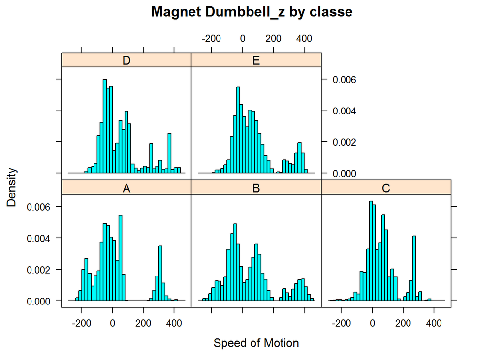

[figure not shown]

Model I

Based on data exploration, I ran a tree model, which will be compared with other model to see any performance imporvement or difference.

```r
## predicting with selected variables
library(rattle)
g <- classe ~ total_accel_dumbbell +magnet_belt_y + accel_arm_z + yaw_dumbbell  + gyros_dumbbell_y + magnet_dumbbell_z + total_accel_dumbbell + accel_arm_z

model_with_tree1 <- train(g, data = training_final_clean, method = 'rpart')

predicted_outcome1 <- predict(model_with_tree1, testing_final_clean)

outcome_value_with_tree1 <- confusionMatrix(predicted_outcome1, testing_final_clean$classe)$overall[['Accuracy']]
print(outcome_value_with_tree1)
```

```
## [1] 0.41823
```

Model II Here is a model with all variables from training dataset. Key point to be noted is that there is very small difference between training and testing outcome by model. But performance in general is not good since accurace is around 50%.

```r
##Decision Tree Model
model_with_tree <- train(classe ~ . , data = training_final_clean, method = 'rpart')

predicted_outcome11 <- predict(model_with_tree, training_final_clean)
outcome_value_with_tree11 <- confusionMatrix(predicted_outcome11, training_final_clean$classe)$overall[['Accuracy']]
print(outcome_value_with_tree11)
```

```
## [1] 0.4944965
```

```r
predicted_outcome22 <- predict(model_with_tree, testing_final_clean)
outcome_value_with_tree22 <- confusionMatrix(predicted_outcome22, testing_final_clean$classe)$overall[['Accuracy']]
print(outcome_value_with_tree22)
```

```
## [1] 0.4987765
```

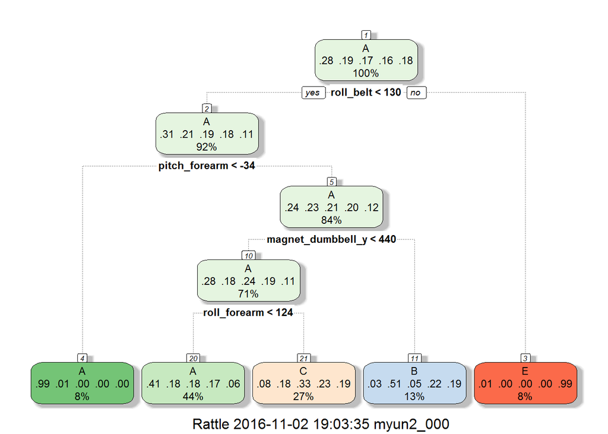

Model III Random forest demonstrated a outstanding performance over here. And there is no overfitting situation since performance difference between training and testing set is minimal. Howevere, there is many different types of dangers. No.1 is interpretability is very low, not to mention that visualization is tricky. No.2 disadvantage is that we don’t even know what is exactly going one inside model.

```r
library(randomForest)
set.seed(777)
model_fit_out <- randomForest(classe ~ ., data = training_final_clean, ntree = 777)

prediction1 <- predict(model_fit_out, training_final_clean, type = "class")
outcome_value_training_1 <- confusionMatrix(prediction1, training_final_clean$classe)$overall[['Accuracy']]
print(outcome_value_training_1)
```

```
## [1] 1
```

```r
prediction2 <- predict(model_fit_out , testing_final_clean, type = "class")
outcome_value_testing_2 <- confusionMatrix(prediction2, testing_final_clean$classe)$overall[['Accuracy']]
print(outcome_value_testing_2)
```

```
## [1] 0.9936786
```

So called too good to be true. This model may not be best model in real world. Thus, we may want to do something further on sampling design (k fold, random sampling, bagging for minimizing bias and distortion). It seems that, based on two models’ performance between training and testing set, it is highly likely to be the case data itself is not representing real world or too much connectedness between them.